# Africa Health Review

Morgan Mureithi

2025-05-19

#QUESTION 1 #Importing the HIV_data 2000-2023

```r
library(readr)
library(dplyr)
```

```r
library(stringr)
library(ggplot2)
data_HIV <- read.csv(file.choose())
View(data_HIV)
```

#Separating Values with the Ranges in the Value column

```r
data_HIV <- data_HIV %>%
  mutate(
    Infected = str_trim(str_extract(Value,"^[^\\[]+")),
    Range_value = str_extract(Value,"\\[.*\\]")
  )
View(data_HIV)
```

#Replacing ‘No data’ with zero

```r
data_HIV<-data_HIV %>%
  mutate(
    Infected = ifelse(Infected == 'No data',0,Infected)
  )
View(data_HIV)
```

#Handling Censored-data(Non-Exact values in the Value column,using Tobit Model)

```r
Censored_data<-data_HIV %>%
  filter(str_detect(Infected,"<"))%>%
  distinct(Infected)
View(Censored_data)
summary(data_HIV$Infected)
```

```
##    Length     Class      Mode
##      1552 character character
```

```r
data_HIV<-data_HIV %>%
  mutate(Infected = str_trim(Infected),
         Censored = str_detect(Infected,"<"),
         New_Infected = str_replace(Infected,"<",""))
unique(data_HIV$New_Infected)
```

```
##   [1] "320 000"   "300 000"   "250 000"   "190 000"   "140 000"   "81 000"
##   [7] "82 000"    "85 000"    "94 000"    "100 000"   "120 000"   "68 000"
##  [13] "69 000"    "71 000"    "66 000"    "63 000"    "95 000"    "97 000"
##  [19] "99 000"    "110 000"   "130 000"   "150 000"   "360 000"   "350 000"
##  [25] "270 000"   "0"         "420 000"   "430 000"   "440 000"   "460 000"
##  [31] "520 000"   "610 000"   "720 000"   "510 000"   "500 000"   "490 000"
##  [37] "530 000"   "570 000"   "86 000"    "200"       "100"       "4000"
##  [43] "3800"      "3700"      "3500"      "2700"      "2200"      "1800"
##  [49] "1500"      "26 000"    "24 000"    "22 000"    "21 000"    "15 000"
##  [55] "10 000"    "5700"      "2400"      "13 000"    "14 000"    "17 000"
##  [61] "25 000"    "27 000"    "620 000"   "650 000"   "660 000"   "860 000"
##  [67] "51 000"    "52 000"    "47 000"    "41 000"    "34 000"    "330 000"
##  [73] "310 000"   "280 000"   "90 000"    "73 000"    "23 000"    "19 000"
##  [79] "35 000"    "37 000"    "1 400 000" "1 500 000" "1 600 000" "1 700 000"
##  [85] "38 000"    "43 000"    "220 000"   "76 000"    "62 000"    "57 000"
```

[output cut: 33 more lines]

```r
data_HIV$New_Infected<-as.numeric(gsub(" ","",data_HIV$New_Infected))
library(AER)
data_HIV$CensoringThreshold<-ifelse(data_HIV$Censored == TRUE,
                                    ifelse(data_HIV$New_Infected <= 100,100,
                                           ifelse(data_HIV$New_Infected <= 200,
                                                  200,500))
                                    ,NA)
formula<-as.formula("New_Infected ~ ParentLocationCode + Period ")
model<-tobit(formula,data=data_HIV,left = min(data_HIV$CensoringThreshold,
                                              na.rm = TRUE))
print(summary(model))
```

```
##
## Call:
## tobit(formula = New_Infected ~ ParentLocationCode + Period, left = min(data_HIV$CensoringThreshold,
##     na.rm = TRUE), data = data_HIV)
##
## Observations:
##          Total  Left-censored     Uncensored Right-censored
##           1552            407           1145              0
##
## Coefficients:
##                          Estimate Std. Error z value Pr(>|z|)
## (Intercept)            -7.181e+06  4.197e+06  -1.711   0.0871 .
## ParentLocationCodeAMR  -5.093e+05  5.083e+04 -10.020  < 2e-16 ***
## ParentLocationCodeEMR  -4.644e+05  5.853e+04  -7.934 2.13e-15 ***
## ParentLocationCodeEUR  -6.037e+05  4.603e+04 -13.115  < 2e-16 ***
## ParentLocationCodeSEAR -4.143e+05  7.687e+04  -5.390 7.03e-08 ***
## ParentLocationCodeWPR  -8.172e+05  6.081e+04 -13.439  < 2e-16 ***
## Period                  3.785e+03  2.084e+03   1.817   0.0693 .
## Log(scale)              1.334e+01  2.110e-02 632.291  < 2e-16 ***
## ---
## Signif. codes:  0 '***' 0.001 '**' 0.01 '*' 0.05 '.' 0.1 ' ' 1
##
## Scale: 622212
##
## Gaussian distribution
## Number of Newton-Raphson Iterations: 3
## Log-likelihood: -1.715e+04 on 8 Df
## Wald-statistic: 266.1 on 6 Df, p-value: < 2.22e-16
```

```r
data_HIV$Predicted_Infections<-predict(model)
data_HIV$Predicted_Infections<-ifelse(data_HIV$Predicted_Infections < 0,0,
                                      data_HIV$Predicted_Infections)
data_HIV$Predicted_Infections<-ifelse(data_HIV$Censored,
                              pmin(data_HIV$Predicted_Infections,
                                   data_HIV$CensoringThreshold),
                              data_HIV$Predicted_Infections)
data_HIV$HIV_cases<-ifelse(data_HIV$Censored,
                                data_HIV$Predicted_Infections,
                                data_HIV$New_Infected)
View(data_HIV$HIV_cases)
```

#Establishing Countries contributing to 75% of the global burden

```r
Country_data_HIV <- data_HIV %>%
  group_by(Location) %>%
  summarise(Total_HIV_cases = sum(HIV_cases)) %>%
  arrange(desc(Total_HIV_cases))
View(Country_data_HIV)
Country_data_HIV <- Country_data_HIV %>%
  mutate(Cumulative_HIV_cases = cumsum(Total_HIV_cases),
         Global_cases = sum(Total_HIV_cases),
         Cumulative_Percentage = (Cumulative_HIV_cases/Global_cases)* 100)
Leading_Country_Contributor <- Country_data_HIV %>%
  filter(Cumulative_Percentage < 76)
View(Leading_Country_Contributor)
```

#Visualizing Leading Country Contributors to 75% of the Global HIV-Case Burden

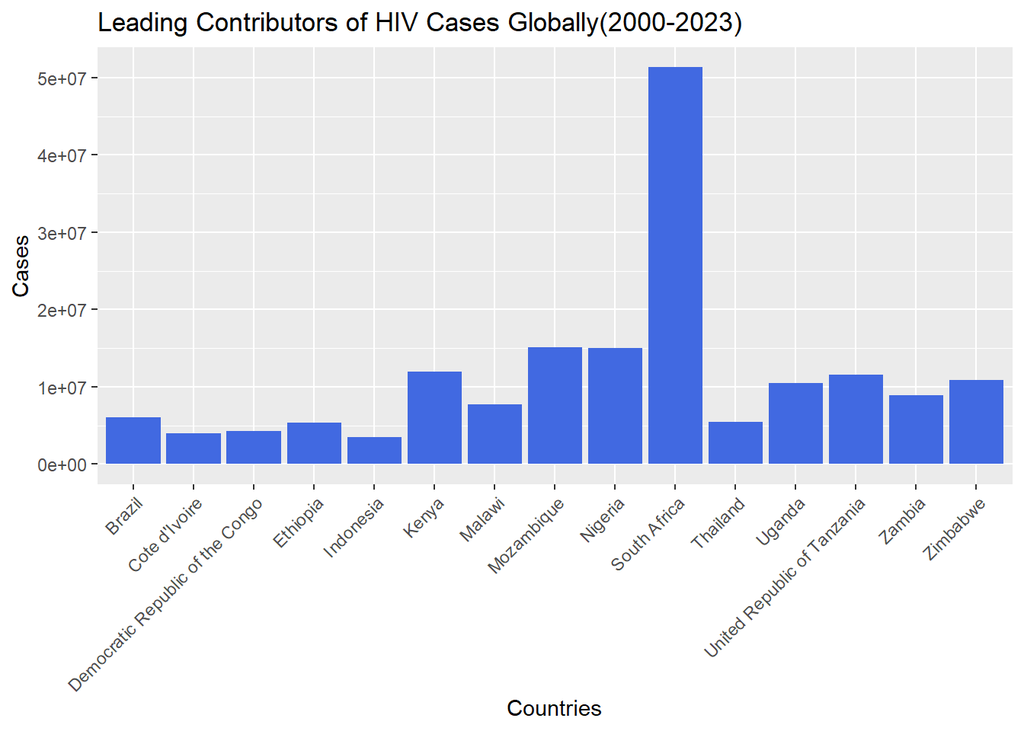

```r
ggplot(Leading_Country_Contributor,aes(x = Location,y = Total_HIV_cases))+
  geom_bar(stat = "identity", fill = "royalblue")+
  labs(title = "Leading Contributors of HIV Cases Globally(2000-2023)",
       x="Countries",
       y="Cases")+
  theme(axis.text.x = element_text(angle = 45, hjust = 1))
```

#Establishing Countries contributing to 75% of the HIV Case burden within WHO #Regions

```r
Region_data_HIV <- data_HIV %>%
  group_by(ParentLocationCode ,Location) %>%
  mutate(Total_HIV_cases = sum(HIV_cases)) %>%
  arrange(ParentLocationCode,desc(Total_HIV_cases)) %>%
  mutate(Region_Total = sum(Total_HIV_cases),
         Cumulative_HIV_cases = cumsum(Total_HIV_cases),
         Cumulative_Percentage = (Cumulative_HIV_cases/Region_Total)* 100
         )
View(Region_data_HIV)
Leading_Region_Contributor <- Region_data_HIV %>%
  filter(Cumulative_Percentage < 76)
View(Leading_Region_Contributor)
```

#Visualizing Leading Country Contributors to the 75% of HIV-Case Burden within Each #WHO Region

[figure not shown]

```r
ggplot(Leading_Region_Contributor,aes(x = Location,y = Total_HIV_cases))+
  geom_bar(stat = "identity", fill = "royalblue")+
  facet_wrap(~ParentLocationCode, scales = "free")+
  labs(title = "Leading Countries to HIV-Case Burden per Region",
       x = "Country",
       y = "HIV_Cases")+
  theme(axis.title = element_text(angle = 45, hjust = 1))
```

#Loading Multidimensional Poverty Headcount Ratio data

```r
library(readxl)
WorldBank_Poverty_data <- read_excel(file.choose(),col_names = FALSE)
View(WorldBank_Poverty_data)
```

#Cleanig Loaded data:WorldBank_Poverty_data by setting headers

```r
WorldBank_Poverty_data <- WorldBank_Poverty_data[-1, ]
na_or_blank <- function(x) {
  is.na(x) | trimws(x) == ""}
WorldBank_Poverty_data[1, ] <- ifelse(
  na_or_blank(WorldBank_Poverty_data[1, ]),
  as.character(WorldBank_Poverty_data[2, ]),
  as.character(WorldBank_Poverty_data[1, ]))
colnames(WorldBank_Poverty_data) <- as.character(WorldBank_Poverty_data[1, ])
WorldBank_Poverty_data <- WorldBank_Poverty_data[-c(1,2), ]
colnames(WorldBank_Poverty_data)
```

```
##  [1] "Region"
##  [2] "Country code"
##  [3] "Economy"
##  [4] "Reporting year"
##  [5] "Survey name"
##  [6] "Survey year"
##  [7] "Survey coverage"
##  [8] "Welfare type"
##  [9] "Survey comparability"
## [10] "Deprivation rate (share of population)"
## [11] "Educational attainment (%)"
## [12] "Educational enrollment (%)"
## [13] "Electricity (%)"
## [14] "Sanitation (%)"
## [15] "Drinking water (%)"
## [16] "Multidimensional poverty headcount ratio (%)"
```

#Merging HIV data with Multidimensional Poverty data

```r
colnames(WorldBank_Poverty_data)[colnames(WorldBank_Poverty_data) ==
                                   "Country code"] <- "Country"
colnames(data_HIV)[colnames(data_HIV) == "SpatialDimValueCode"] <- "Country"
HIV_Poverty_data <- merge(data_HIV,WorldBank_Poverty_data,by = "Country")
View(HIV_Poverty_data)
```

#Checking for Missing value in the Poverty Headcount ratio column in the World Bank #data

```r
is.na(WorldBank_Poverty_data$`Multidimensional poverty headcount ratio (%)`)
```

```
##   [1] FALSE FALSE FALSE FALSE FALSE FALSE FALSE FALSE FALSE FALSE FALSE FALSE
##  [13] FALSE FALSE FALSE FALSE FALSE FALSE FALSE FALSE FALSE FALSE FALSE FALSE
##  [25] FALSE FALSE FALSE FALSE FALSE FALSE FALSE FALSE FALSE FALSE FALSE FALSE
##  [37] FALSE FALSE FALSE FALSE FALSE FALSE FALSE FALSE FALSE FALSE FALSE FALSE
##  [49] FALSE FALSE FALSE FALSE FALSE FALSE FALSE FALSE FALSE FALSE FALSE FALSE
##  [61] FALSE FALSE FALSE FALSE FALSE FALSE FALSE FALSE FALSE FALSE FALSE FALSE
##  [73] FALSE FALSE FALSE FALSE FALSE FALSE FALSE FALSE FALSE FALSE FALSE FALSE
##  [85] FALSE FALSE FALSE FALSE FALSE FALSE FALSE FALSE FALSE FALSE FALSE FALSE
##  [97] FALSE FALSE FALSE FALSE FALSE FALSE FALSE FALSE FALSE FALSE FALSE FALSE
## [109] FALSE FALSE
```

```r
HIV_Poverty_data$`Multidimensional poverty headcount ratio (%)` <- as.numeric(
  HIV_Poverty_data$`Multidimensional poverty headcount ratio (%)`)
```

#Simple Linear Regression to assess the Relationship between people living with HIV #and Poverty HeadCount Ratio

```r
HIV_Poverty <- lm(HIV_cases ~ `Multidimensional poverty headcount ratio (%)`,
                  data = HIV_Poverty_data)
summary(HIV_Poverty)
```

```
##
## Call:
## lm(formula = HIV_cases ~ `Multidimensional poverty headcount ratio (%)`,
##     data = HIV_Poverty_data)
##
## Residuals:
##     Min      1Q  Median      3Q     Max
## -609632  -63654  -50786  -29275 1649283
##
## Coefficients:
##                                                Estimate Std. Error t value
## (Intercept)                                     49999.9    12305.3   4.063
## `Multidimensional poverty headcount ratio (%)`   7575.0      475.7  15.922
##                                                Pr(>|t|)
## (Intercept)                                    5.28e-05 ***
## `Multidimensional poverty headcount ratio (%)`  < 2e-16 ***
## ---
## Signif. codes:  0 '***' 0.001 '**' 0.01 '*' 0.05 '.' 0.1 ' ' 1
##
## Residual standard error: 313600 on 870 degrees of freedom
## Multiple R-squared:  0.2256, Adjusted R-squared:  0.2248
## F-statistic: 253.5 on 1 and 870 DF,  p-value: < 2.2e-16
```

#Preparing data for model fitting by Handling Missing values

```r
HIV_Poverty_data[HIV_Poverty_data == " "] <- NA
HIV_Poverty_data[HIV_Poverty_data == "-"] <- NA
#Converting select columns to Numeric
to_numeric <- c("Multidimensional poverty headcount ratio (%)",
                "Drinking water (%)",
                "Electricity (%)","Educational enrollment (%)",
                "Educational attainment (%)",
                "Deprivation rate (share of population)","Survey year")
HIV_Poverty_data[to_numeric] <- lapply(HIV_Poverty_data[to_numeric], as.numeric)
fill_na_numeric <- c("Multidimensional poverty headcount ratio (%)",
                     "Drinking water (%)",
                     "Electricity (%)","Educational enrollment (%)",
                     "Educational attainment (%)",
                     "Deprivation rate (share of population)","Survey year")
HIV_Poverty_data[fill_na_numeric] <- lapply(HIV_Poverty_data[fill_na_numeric],
                                            function(x) {
  x[is.na(x)] <- 0
  return(x)
})
HIV_Poverty_data$`Sanitation (%)` <- as.numeric(HIV_Poverty_data$`Sanitation (%)`)
HIV_Poverty_data$`Sanitation (%)`[is.na(HIV_Poverty_data$`Sanitation (%)`)] <- 0
HIV_Poverty_data$Country <- as.factor(HIV_Poverty_data$Country)
HIV_Poverty_data <- HIV_Poverty_data %>%
  rename("Income" = "Deprivation rate (share of population)")
```

#Establising Factors contributing to the Poverty Ratio(using Linear Mixed Model) #Scaling Predictor Variables

```r
library(lme4)
HIV_Poverty_data <- HIV_Poverty_data %>%
  rename(
    Multidimensional_poverty = `Multidimensional poverty headcount ratio (%)`,
    Survey_year = `Survey year`
  )
HIV_Poverty_data$Income_scaled <- scale(HIV_Poverty_data$Income)
HIV_Poverty_data$Education_attainment_scaled <- scale(
  HIV_Poverty_data$`Educational attainment (%)`)
HIV_Poverty_data$Sanitation_scaled <- scale(HIV_Poverty_data$`Sanitation (%)`)
HIV_Poverty_data$Electricity_scaled <- scale(HIV_Poverty_data$`Electricity (%)`)
HIV_Poverty_data$Water_scaled <- scale(HIV_Poverty_data$`Drinking water (%)`)
library(standardize)
library(lme4)
Poverty_contributing_factors_model <-  suppressWarnings( lmer(Multidimensional_poverty ~ Income_scaled + Education_attainment_scaled + Electricity_scaled +  Water_scaled + (1 | Country) + (1 | Survey_year),data = HIV_Poverty_data))
summary(Poverty_contributing_factors_model)
```

```
## Linear mixed model fit by REML ['lmerMod']
## Formula:
## Multidimensional_poverty ~ Income_scaled + Education_attainment_scaled +
##     Electricity_scaled + Water_scaled + (1 | Country) + (1 |      Survey_year)
##    Data: HIV_Poverty_data
##
## REML criterion at convergence: -18152.4
##
## Scaled residuals:
##        Min         1Q     Median         3Q        Max
## -1.233e-06 -2.011e-07  4.928e-08  1.850e-07  1.437e-06
##
## Random effects:
##  Groups      Name        Variance  Std.Dev.
##  Country     (Intercept) 1.064e+00 1.032e+00
##  Survey_year (Intercept) 1.302e-03 3.609e-02
##  Residual                1.328e-12 1.152e-06
## Number of obs: 872, groups:  Country, 109; Survey_year, 5
##
## Fixed effects:
##                             Estimate Std. Error t value
## (Intercept)                  13.0935     0.1004  130.36
## Income_scaled                 8.6354     0.2395   36.06
## Education_attainment_scaled   4.9679     0.1637   30.35
## Electricity_scaled            7.6634     0.2921   26.23
## Water_scaled                  3.1686     0.1672   18.95
##
## Correlation of Fixed Effects:
##             (Intr) Incm_s Edct__ Elctr_
## Income_scld  0.001
## Edctn_ttnm_  0.004  0.302
## Elctrcty_sc -0.003 -0.775 -0.529
## Water_scald -0.002 -0.201 -0.268 -0.191
## optimizer (nloptwrap) convergence code: 0 (OK)
## Model failed to converge with max|grad| = 1.81908 (tol = 0.002, component 1)
## Model is nearly unidentifiable: very large eigenvalue
##  - Rescale variables?
```

#QUESTION 2 #Loading the data

```r
library(readr)
library(dplyr)
library(stringr)
library(ggplot2)
Neo_UnderFive<-read.csv(file.choose())
View(Neo_UnderFive)
```

#Filtering World Data to EAC countries

```r
unique(Neo_UnderFive$Geographic.area)
```

```
##   [1] "Afghanistan"
##   [2] "Angola"
##   [3] "Anguilla"
##   [4] "Albania"
##   [5] "Andorra"
##   [6] "United Arab Emirates"
##   [7] "Argentina"
##   [8] "Armenia"
##   [9] "Antigua and Barbuda"
##  [10] "Australia"
##  [11] "Austria"
##  [12] "Azerbaijan"
##  [13] "Burundi"
##  [14] "Belgium"
##  [15] "Benin"
```

[output cut: 220 more lines]

```r
EAC_Neo_UnderFive<-Neo_UnderFive %>%
  filter(Geographic.area %in% c("Burundi","Democratic Republic of the Congo","Ethiopia",
         "Kenya","Rwanda","South Sudan","Somalia","Uganda"))
View(EAC_Neo_UnderFive)
```

#Having Year as Year(stand-alone)

```r
EAC_Neo_UnderFive$YEAR<-as.numeric(sapply(
  str_split(EAC_Neo_UnderFive$Series.Year,pattern = "-"),
  function(x) max(as.numeric(x))))
```

#To filter latest Country Estimates

```r
library(sp)
library(viridisLite)
Latest_estimate<-EAC_Neo_UnderFive %>%
  group_by(Geographic.area) %>%
  filter(YEAR == max(YEAR))
View(Latest_estimate)
unique(Latest_estimate$Indicator)
```

```
## [1] "Neonatal mortality rate"   "Under-five mortality rate"
```

#Filtering to Neonatal Data Indicator

```r
Latest_estimate_Neo<-Latest_estimate %>%
  filter(Indicator == 'Neonatal mortality rate')
View(Latest_estimate_Neo)
```

#Filtering to UnderFive Indicator

```r
Latest_estimate_UnderFive<-Latest_estimate %>%
  filter(Indicator == 'Under-five mortality rate')
View(Latest_estimate_UnderFive)
```

#Preparing for Visualization using Shapefile

```r
library(shapefiles)
data_SP <- read.shapefile("C:/Users/hp/Downloads/Shapefile/ne_50m_admin_0_countries")
View(data_SP$dbf$dbf)
unique(data_SP$dbf$dbf$NAME)
```

```
##   [1] Zimbabwe                  Zambia
##   [3] Yemen                     Vietnam
##   [5] Venezuela                 Vatican
##   [7] Vanuatu                   Uzbekistan
##   [9] Uruguay                   Micronesia
##  [11] Marshall Is.              N. Mariana Is.
##  [13] U.S. Virgin Is.           Guam
##  [15] American Samoa            Puerto Rico
##  [17] United States of America  S. Geo. and the Is.
##  [19] Br. Indian Ocean Ter.     Saint Helena
##  [21] Pitcairn Is.              Anguilla
##  [23] Falkland Is.              Cayman Is.
##  [25] Bermuda                   British Virgin Is.
##  [27] Turks and Caicos Is.      Montserrat
##  [29] Jersey                    Guernsey
```

[output cut: 107 more lines]

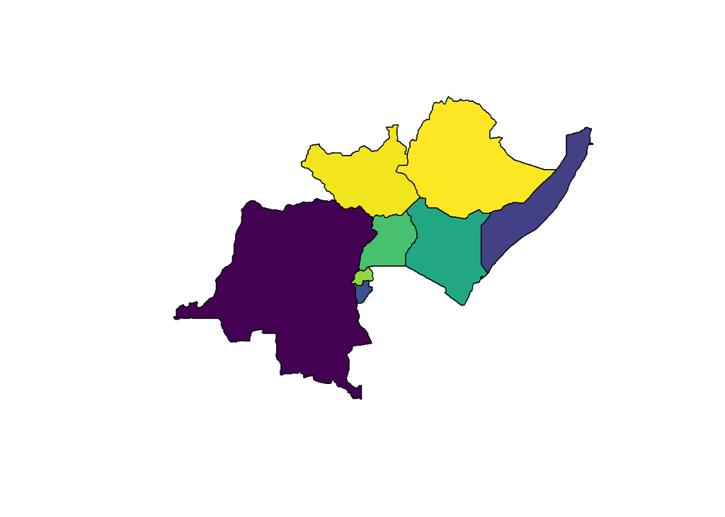

```r
Latest_estimate_Neo$Geographic.area[Latest_estimate_Neo$Geographic.area == "Democratic Republic of the Congo"] <- "Dem. Rep. Congo"
Latest_estimate_Neo$Geographic.area[Latest_estimate_Neo$Geographic.area == "South Sudan" ] <- "S. Sudan"
correctly_matched <- Latest_estimate$Observation.Value[match(data_SP$dbf$dbf$NAME, Latest_estimate$Geographic.area)]
data_SP$dbf$dbf$Observation.Value <- correctly_matched
data_SP$dbf$dbf$Observation.Value <- Latest_estimate_Neo$Observation.Value[
  match(data_SP$dbf$dbf$NAME,Latest_estimate_Neo$Geographic.area)]
color_palette <- viridis(100)
EAC_countries <- c("Burundi", "Dem. Rep. Congo", "Ethiopia",
                   "Kenya", "Rwanda", "S. Sudan", "Somalia", "Uganda")
EAC_only <- data_SP$dbf$dbf$NAME %in% EAC_countries
East_Africa <- list(
  shp = list(shp = data_SP$shp$shp[EAC_only]),
  dbf = list(dbf = data_SP$dbf$dbf[EAC_only, ])
)
Collours <- color_palette[as.numeric(cut(East_Africa$dbf$dbf$Observation.Value, breaks = 100))]
plot.new()
xrange <- range(unlist(lapply(East_Africa$shp$shp, function(x) x$points[,1])))
yrange <- range(unlist(lapply(East_Africa$shp$shp, function(x) x$points[,2])))
plot.window(xlim = xrange, ylim = yrange, asp = 1)
for (i in 1:length(East_Africa$shp$shp)) {
  country <- East_Africa$shp$shp[[i]]
  parts <- country$parts
  n_parts <- length(parts)
  if (n_parts == 1) {
    polygon(country$points, col = Collours[i], border = "black")
  } else {for (p in 1:n_parts) {
    start <- parts[p]+1
    end <- ifelse(p == n_parts, nrow(country$points), parts[p+1])
    polygon(country$points[start:end, ], col = Collours[i], border = "black")}}}
```

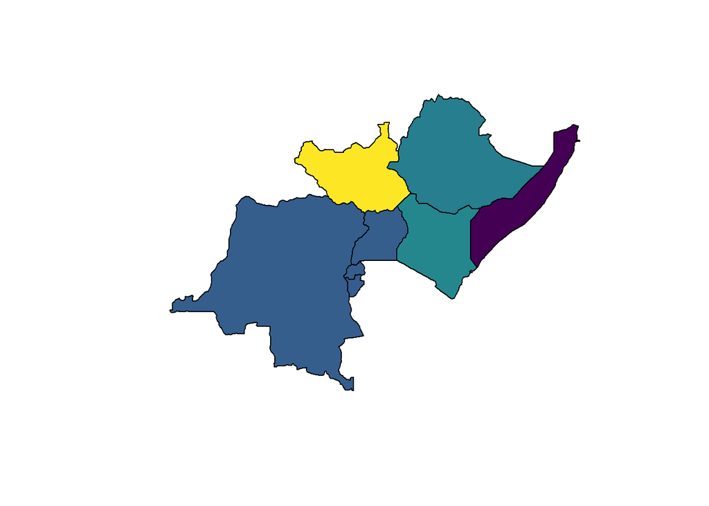

```r
#Under_Five Mortality Indicator
Latest_estimate_UnderFive$Geographic.area[Latest_estimate_UnderFive$Geographic.area == "Democratic Republic of the Congo"] <- "Dem. Rep. Congo"
Latest_estimate_UnderFive$Geographic.area[Latest_estimate_UnderFive$Geographic.area == "South Sudan" ] <- "S. Sudan"
matched_correctly <- Latest_estimate_UnderFive$Observation.Value[match(data_SP$dbf$dbf$NAME, Latest_estimate_UnderFive$Geographic.area)]
data_SP$dbf$dbf$Observation.Value <- matched_correctly
data_SP$dbf$dbf$Observation.Value <- Latest_estimate_UnderFive$Observation.Value[
  match(data_SP$dbf$dbf$NAME,Latest_estimate_UnderFive$Geographic.area)]
color_palette <- viridis(100)
EAC_countries <- c("Burundi", "Dem. Rep. Congo", "Ethiopia",
                   "Kenya", "Rwanda", "S. Sudan", "Somalia", "Uganda")
EAC_only <- data_SP$dbf$dbf$NAME %in% EAC_countries
East_Africa <- list(
  shp = list(shp = data_SP$shp$shp[EAC_only]),
  dbf = list(dbf = data_SP$dbf$dbf[EAC_only, ])
)
Collours <- color_palette[as.numeric(cut(East_Africa$dbf$dbf$Observation.Value, breaks = 100))]
plot.new()
xrange <- range(unlist(lapply(East_Africa$shp$shp, function(x) x$points[,1])))
yrange <- range(unlist(lapply(East_Africa$shp$shp, function(x) x$points[,2])))
plot.window(xlim = xrange, ylim = yrange, asp = 1)
for (i in 1:length(East_Africa$shp$shp)) {
  country <- East_Africa$shp$shp[[i]]
  parts <- country$parts
  n_parts <- length(parts)
  if (n_parts == 1) {
    polygon(country$points, col = Collours[i], border = "black")
  } else {for (p in 1:n_parts) {
    start <- parts[p]+1
    end <- ifelse(p == n_parts, nrow(country$points), parts[p+1])
    polygon(country$points[start:end, ], col = Collours[i], border = "black")}}}
```

#Visualizing Neonatal Mortality Trend across EAC

```r
View(EAC_Neo_UnderFive)
unique(EAC_Neo_UnderFive$Indicator)
```

```
## [1] "Neonatal mortality rate"   "Under-five mortality rate"
```

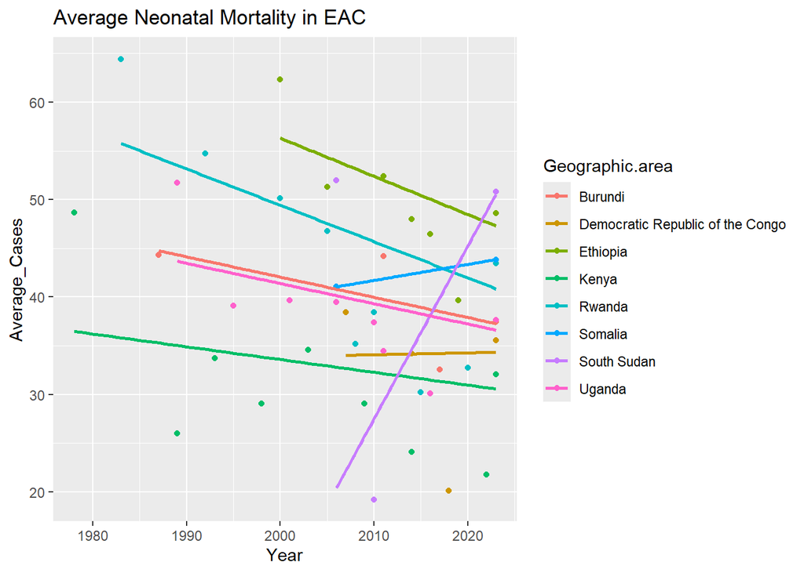

```r
NeoNatal_Mortality <- EAC_Neo_UnderFive %>%
  filter(Indicator == 'Neonatal mortality rate')
Avg_NeoNatal_Mortality <- NeoNatal_Mortality %>%
  group_by(Geographic.area,YEAR) %>%
  mutate(Avg_Cases = mean(Observation.Value))
ggplot(Avg_NeoNatal_Mortality,aes(x = YEAR, y = Avg_Cases ,colour = Geographic.area))+
  geom_point()+
  geom_smooth(method = "lm" ,se = FALSE)+
  labs(title = "Average Neonatal Mortality in EAC",
       x = "Year",
       y = "Average_Cases")
```

#Visualizing Under Five Mortality Trend across EAC

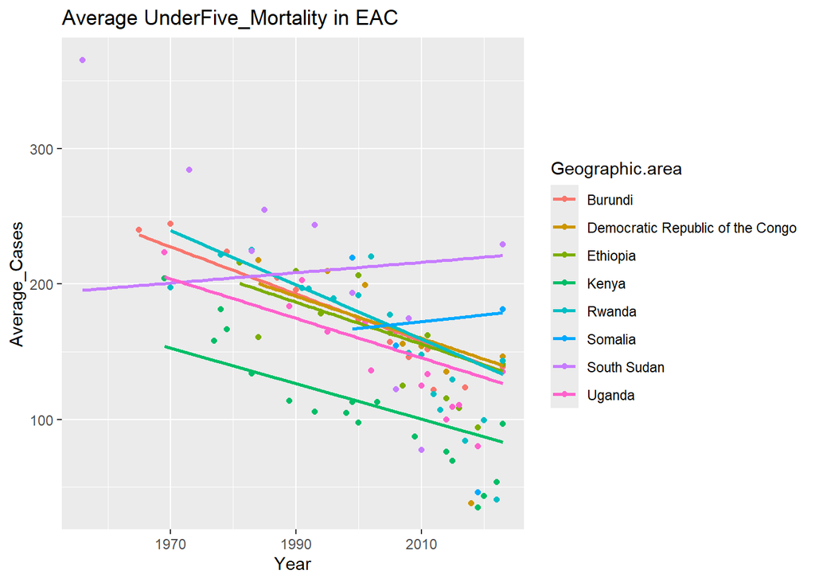

```r
UnderFive_Mortality <- EAC_Neo_UnderFive %>%
  filter(Indicator == 'Under-five mortality rate')
Avg_UnderFive_Mortality <- UnderFive_Mortality %>%
  group_by(Geographic.area,YEAR) %>%
  mutate(Avg_Cases = mean(Observation.Value))
ggplot(Avg_UnderFive_Mortality,aes(x = YEAR, y = Avg_Cases ,colour = Geographic.area))+
  geom_point()+
  geom_smooth(method = "lm" ,se = FALSE)+
  labs(title = "Average UnderFive_Mortality in EAC",
       x = "Year",
       y = "Average_Cases")
```

#Mortality Trend Findings

# 1.Under_Five Mortality:South Sudan and Somalia,have the highest average

#Under_Five Mortality rates,while the rest of the countries have declining cases.

#2.Neo-natal mortality:South Sudan,Ethiopia and Somalia have highest average #Neo-natal cases,while,Rwanda,Uganda,Burundi and Kenya recorded declining cases. #Democratic Republic of Congo has for many years,registered slightly unchanging Neo-natal deaths.